# [업무자동화] R로 마우스를 조작하려면 rMouse

R rmouse automation mouse

java 의존성이 없는 KeyboardSimulator패키지가 소개되었습니다. Windows 에서만 동작합니다.

true  
2018-10-08

[figure not shown]

# 업데이트

- `java` 의존성이 없는 KeyboardSimulator 패키지가 소개되었습니다. Windows 에서만 동작합니다.

### 한줄요약

1. R 스크립트로 키보드/마우스를 다루는 rMouse 패키지를 사용할 수 있다.

[메일을 보내는 포스트](https://mrchypark.github.io/post/%EC%97%85%EB%AC%B4%EC%9E%90%EB%8F%99%ED%99%94-r%EB%A1%9C-%EC%9D%B4%EB%A9%94%EC%9D%BC%EC%9D%84-%EB%B3%B4%EB%82%B4%EB%A0%A4%EB%A9%B4-sendgridr/)를 작성하고 아니 업무자동화 키워드에 해당하는 패키지에 관심이 생겼습니다. 많은 업무가 웹에서 이루어진다면, 웹 api로 제공해주거나 브라우저 자동화 등을 사용할 텐데요. 어쩔 수 없이 브라우저 밖의 프로그램 들을 자동화할 일들이 있습니다. 이때 사용하는 것이 키보드/마우스 메크로 입니다.

R 스크립트로 동작하는 것이 없는지 찾아봤는데요. 놀랍게도 있었습니다! 바로 [rMouse](https://cran.r-project.org/web/packages/rMouse/) 패키지입니다. 무려 작년 중순께 나온 싱싱한(?) 패키지입니다. 놀라운건 코드 공개를 안하셔서 문의를 메일로 해야 하네요 ㅎㅎ

### 설치

자바 의존성이 있는 패키지라 자바와 rJava 패키지가 필요합니다. [지난 포스트](https://mrchypark.github.io/post/rtips-windows%EC%97%90%EC%84%9C-rjava-%EC%8A%A4%ED%8A%B8%EB%A0%88%EC%8A%A4-%EC%97%86%EC%9D%B4-%EC%84%A4%EC%B9%98%ED%95%98%EA%B8%B0/)에 설명이 잘 나와있어서 이제 자바 의존성 패키지가 두렵지 않습니다!

```r
install.packages("rMouse")
library(rMouse)
setAutoDelay()
```

처음에 패키지가 실행되는 시간이 필요해서 `setAutoDelay()` 함수를 제공해준다고 합니다. `library(rMouse)` 다음에 연속으로 붙여 놓으면 좋겠네요!

### 기능 설명

`rMouse` 패키지는 크게 3가지 기능과 한 가지 중요한 옵션을 제공합니다.

1. 딜레이
2. 마우스 입력
3. 키보드 입력
4. 긴급 중단 옵션

딜레이 먼저 볼까요?

#### 딜레이

`Sys.sleep()` 함수와 같은 기능을 제공하는 `delay()` 함수가 있습니다. 이건 설명이 별로 필요없겠네요.

```r
delay(1000)
```

#### 긴급 중단 옵션

이제 다른 것들을 설명하기 전에 긴급 중단 옵션을 먼저 볼까 합니다. `rMouse` 패키지에서 제공하는 거의 모든 함수는 `failSafe` 파라미터를 가지고 있습니다. 기본 값은 `T`인데요. 마우스를 화면 왼쪽 위 끝(x = 0, y = 0)으로 옮기면 스크립드를 중단하겠다는 뜻입니다. 키보드/마우스 자동화 단계에서 얼마나 긴급 중단이 중요한지는 아마 사용해보셨다면 잘 아실겁니다. 자기 마음대로 움직이는데, 중간에 뭘 할 수 없으면 엄청 답답하거든요.ㅎㅎ

#### 키보드 입력

키보드 입력은 총 2가지 함수를 제공합니다. `type()` 함수와 `specialKey()` 함수입니다. 직접 키를 입력하는 함수와 기능 키를 입력하는 함수군요 키 입력 함수는 자바와 R의 키값이 달라서 많은 특수 문자들(+한글)이 동작하지 않는다고 합니다. 엉엉

```r
type("This is a sentence.")  # 대부분의 특수 문자를 제외한 글자들로 영어만 가능
type("!")                    # 에러가 발생함
specialKey("ESC")            # ESC 키 사용
specialKey("ENTER")          # ENTER 키 사용
```

#### 마우스 입력

마우스 입력은 어떤 좌표로 움직이고, 오른쪽/왼쪽 클릭을 수행하는 함수를 제공합니다.

```r
move(0,0)       # 모니터 가장 왼쪽 위(0,0)로 이동
move(50,30)     # 좌표 x = 50, y = 30 로 이동
left()          # 왼쪽 클릭
right()         # 오른쪽 클릭
```

마우스의 위치를 잡아주는 `coord()` 함수와 `pos()` 함수도 제공합니다. `coord()` 함수는 `list` 자료형으로 x, y 위치를 제공하구요. `pos()` 함수는 x, y 위치를 콘솔에 출력해줍니다. `pos()` 함수가 `coord()` 함수로 만든 `cat()`(출력 함수) 함수인 것으로 보아 편한 방식으로 사용하시면 좋을 것 같습니다.

```r
coord()       # 리스트 자료형으로 결과 제공
pos()         # 콘솔에 출력
```

```
#> move(x,y)
```

```r
# 3초 간격으로 3번 기록
record(n = 3, timeInterval = 3)
```

[output not shown]

옵션에 *n*과 *timeInterval* 이 있는데요. *n*은 기록하는 갯수라는 뜻입니다. 이게 아마도 클릭하는 횟수를 흉내내려는 것 같네요. *timeInterval* 은 클릭을 잡지 못하니 위치를 캐치하기 위해서 *어느 시간 마다 동작함*같은 방식을 사용한 것 같습니다. 아래 이미지를 보시면 조금 감이 오실 것 같습니다.

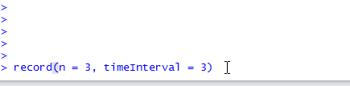

### 사용평

간단한 자동화를 위해서는 제공하는 기능도 단순하고 이해하기 쉬워서 좋을 것 같습니다. 하지만 드래그를 지원하지 않는다던가, 제대로된 **기록** 기능을 제공하지 않는 점이 아쉬운 것 같습니다.

### 매크로 프로그램들

윈도우로만 한정하면 GUI까지 잘 제공하는 무료 프로그램이 몇 개 있습니다.

#### G Macro

[G Macro](http://www.gmacro.er.ro/)은 2버전이 2003년에 나오고 지금도 관리자 권한으로 실행하면 win10에서 잘 동작한다고 합니다. [나무위키](https://namu.wiki/w/G%20Macro)에 자세하게 설명이 잘 나와있네요.

[figure not shown]

#### 키보드/마우스 매크로

[키보드/마우스 매크로](http://blog.daum.net/pg365/250)라는 이름으로 v1, v2, 비활성화 윈도우 버전 총 3개를 제공합니다. v1은 단순 버전, v2는 고급 버전이라고 하네요.

[figure not shown]

이것도 12년 정도에 제작하시고 이후에 업데이트가 없긴 하군요. 그래도 무리없이 작동하는 것 같습니다.

#### 기타

오토 마우스류라고 불리는 프로그램들이 게임 쪽에서 많이 사용되었습니다. 대표적으로는 [졸라빨라](https://namu.wiki/w/%EC%A1%B8%EB%9D%BC%EB%B9%A8%EB%9D%BC) 같은 프로그램이 있는데요. 이것도 개발이 중간에 중지된 모양입니다. 그리고 게임 광클에 맞게 개발된 프로그램이라 업무자동화에는 조금 맞지 않습니다.

#### 맥용은 없는가?

맥은 검색해보면 몇 가지 나오기는하는데, 제가 시도해보지를 못하고 있네요. 맥은 [AppleScript](https://support.apple.com/ko-kr/HT202905)와 [Automator](http://macnews.tistory.com/2049)를 자체적으로 지원합니다. 뭔가 다른 세상 이야기 같네요. 혹시 잘 정리된 글이 있으면 추가, 공유하도록 하겠습니다. 사실 한국에서 화면 자동화 니즈는 윈도우 전용 클라이언트들(은행의 기업용 프로그램이라던가..)이기 때문에 필요성을 못 느끼겠네요.

언제나처럼, 오타 질문 등등 대환영입니다.

Comment on this article Share: